# a3_task3_katelyn_toigo

Katelyn Toigo

10/31/2020

```r
knitr::opts_chunk$set(echo = TRUE)
library(tidyverse)
library(here)
library(janitor)
library(kableExtra)
library(lubridate)
```

## Summary

I will be analyzing the urchins.csv data. I will be using version control, project management, data wrangling, analysis, and visualization skills. I will analyze urchin size vs. species (histogram, boxplot, and exploratory table) and counts by site and year (summary table and exploratory graph (histogram)).

## Read in the data

Read in the urchins.csv file and also clean the names so that they are all in lowercase_snakecase (to make working with the data easier).

```r
urchins <- read_csv(here("data", "urchins.csv")) %>%
  clean_names()
```

## Exploratory data visualization

### Faceted histogram

Comparing common_name vs. size.

Facet_wrap causes there to be two separate histograms, one for each common name.

labs() allows you to change the axis labels.

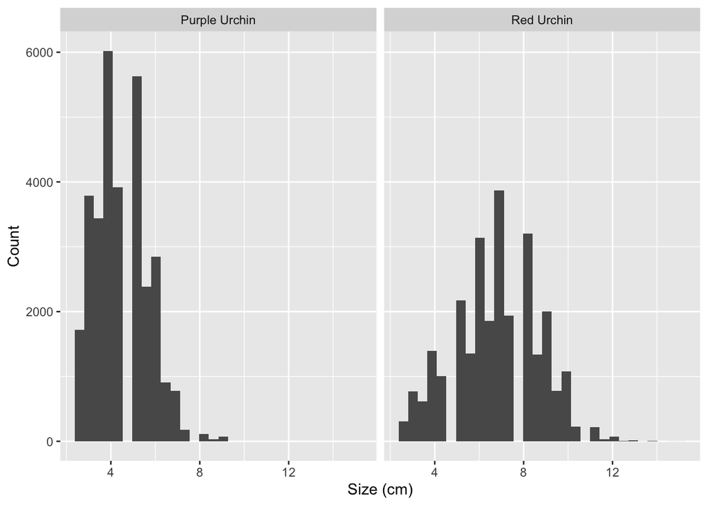

```r
ggplot(data = urchins, aes(x = size)) +
  geom_histogram() +
  facet_wrap(~common_name) +
  labs(x = "Size (cm)", y = "Count")
```

### Boxplot

Common name vs. size

labs() to label the axis

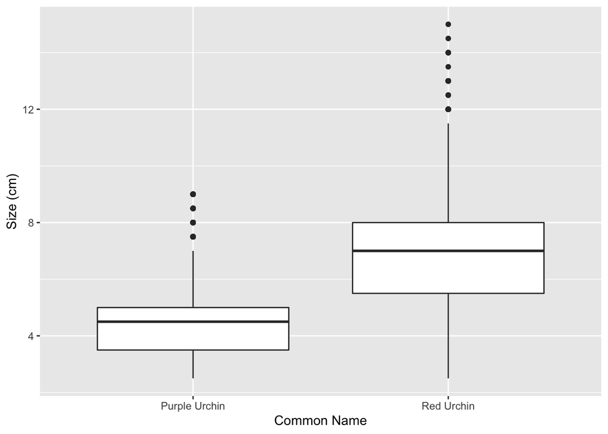

```r
ggplot(data = urchins, aes(x = common_name, y = size)) +
  geom_boxplot()+
  labs(x = "Common Name", y = "Size (cm)")
```

## Descriptive Statistics Table

kable_styling() to make the graph format better in the knitted document

```r
urchin_table <- urchins %>%
  group_by(common_name) %>%
  summarize(mean = mean(size), median = median(size), sd = sd(size), n = n())
  kbl(urchin_table) %>%
  kable_styling()
```

| common_name | mean | median | sd | n |
| --- | --- | --- | --- | --- |
| Purple Urchin | 4.469797 | 4.5 | 1.175264 | 31805 |
| Red Urchin | 6.776489 | 7.0 | 1.891343 | 27408 |

Purple urchins appear to be, on average, smaller in size than the red urchin (purple urchins have a mean that is 2.306692 cms smaller and their mean is 41% lower (this was calculated by finding the difference between the two means, dividing by their average and multiplying by 100)). Purple urchins also have a smaller standard deviation and spread than the red urchins. Both species have a relatively normal distribution when looking at the histogram.

## Explore purple urchin counts by site and year

Basic data wrangling - filter for only purple urchins, create a new columns called Date, year, and site_full. Mutate is used to create the new columns. mdy is used becasue the original data has dates in month, day, year order.

```r
purple_urchins <- urchins %>%
  filter(common_name == "Purple Urchin") %>%
  mutate(Date = mdy(date)) %>%
  mutate(year = year(Date)) %>%
  mutate(site_full = case_when(
    site == "NAPL" ~ "Naples Reef",
    site == "AQUE" ~ "Arroyo Quemado Reef",
    site == "CARP" ~ "Carpinteria Reef",
    site == "MOHK" ~ "Mohawk Reef",
    site == "IVEE" ~ "Isla Vista Reef"
  ))
```

## Summary table containing total number of purple urchins by site and year

Group_by() is used first and followed by count() which basically combines group_by, summarize, and n all together in one function.

```r
purple_table <- purple_urchins %>%
  group_by(site_full, year) %>%
  count(site_full, year)
purple_table
```

```
## # A tibble: 61 x 3
## # Groups:   site_full, year [61]
##    site_full            year     n
##    <chr>               <dbl> <int>
##  1 Arroyo Quemado Reef  2008    67
##  2 Arroyo Quemado Reef  2009   926
##  3 Arroyo Quemado Reef  2010   921
##  4 Arroyo Quemado Reef  2011   887
##  5 Arroyo Quemado Reef  2012   764
##  6 Arroyo Quemado Reef  2013   434
##  7 Arroyo Quemado Reef  2014   410
##  8 Arroyo Quemado Reef  2015   400
##  9 Arroyo Quemado Reef  2016   342
## 10 Arroyo Quemado Reef  2017   406
## # … with 51 more rows
```

## Exploratory graph of counts of purple urchins recorded at each site over time

Using a histogram set to 25 bins because it allowed for nice viewing between the years. Facet wrap is used to separate each location into its own histogram.

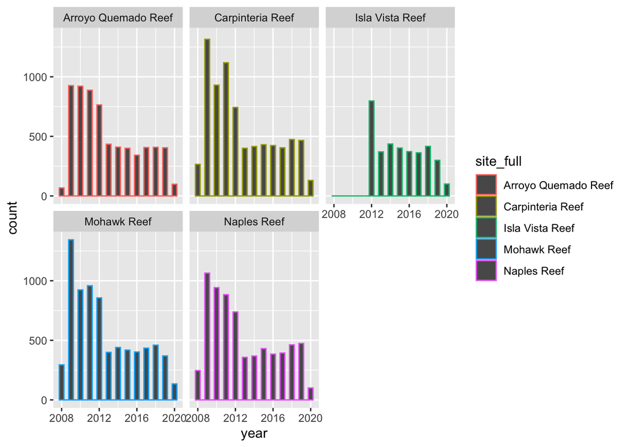

```r
ggplot(data = purple_urchins, aes(x = year, color = site_full)) +
  geom_histogram(bins=25) +
  facet_wrap(~site_full)
```